# World Bank Education Data Analysis

## Intro to Python

```python
print("World Bank")
print(5)
print(5.5)
print(True)
```

```
World Bank
5
5.5
True
```

## Loading the Data

Data taken from [World Bank Repository](https://https://data.worldbank.org/topic/education?cid=EXT_TWBN_D_EXT)

Download data

Upload data

Read data into pandas

```python
import pandas as pd

main_data = pd.read_csv("/content/API_4_DS2_en_csv_v2_1741864.csv", skiprows= 4)
main_data.head()
```

|  | Country Name | Country Code | Indicator Name | Indicator Code | 1960 | 1961 | 1962 | 1963 | 1964 | 1965 | 1966 | 1967 | 1968 | 1969 | 1970 | 1971 | 1972 | 1973 | 1974 | 1975 | 1976 | 1977 | 1978 | 1979 | 1980 | 1981 | 1982 | 1983 | 1984 | … |
| --- | --- | --- | --- | --- | --- | --- | --- | --- | --- | --- | --- | --- | --- | --- | --- | --- | --- | --- | --- | --- | --- | --- | --- | --- | --- | --- | --- | --- | --- | --- |
| 0 | Aruba | ABW | Population ages 15-64 (% of total population) | SP.POP.1564.TO.ZS | 53.669919 | 54.056784 | 54.383281 | 54.710292 | 55.119933 | 55.631102 | 56.075544 | 56.703126 | 57.414449 | 58.086708 | 58.679715 | 59.55249 | 60.248997 | 60.890062 | 61.639241 | 62.566563 | 63.078929 | 63.850512 | 64.825383 | 65.810270 | 66.635051 | 67.185101 | 67.578450 | 67.804376 | 67.945127 | … |
| 1 | Aruba | ABW | Population ages 0-14 (% of total population) | SP.POP.0014.TO.ZS | 43.847190 | 43.358346 | 42.925745 | 42.488756 | 41.950133 | 41.290098 | 40.689595 | 39.900095 | 39.011064 | 38.134727 | 37.316086 | 36.08681 | 35.015040 | 33.989011 | 32.869085 | 31.577559 | 30.878421 | 29.907564 | 28.734007 | 27.542514 | 26.514244 | 25.829247 | 25.314207 | 25.001206 | 24.785155 | … |
| 2 | Aruba | ABW | Unemployment, total (% of total labor force) (... | SL.UEM.TOTL.ZS | NaN | NaN | NaN | NaN | NaN | NaN | NaN | NaN | NaN | NaN | NaN | NaN | NaN | NaN | NaN | NaN | NaN | NaN | NaN | NaN | NaN | NaN | NaN | NaN | NaN | … |
| 3 | Aruba | ABW | Unemployment, male (% of male labor force) (mo... | SL.UEM.TOTL.MA.ZS | NaN | NaN | NaN | NaN | NaN | NaN | NaN | NaN | NaN | NaN | NaN | NaN | NaN | NaN | NaN | NaN | NaN | NaN | NaN | NaN | NaN | NaN | NaN | NaN | NaN | … |
| 4 | Aruba | ABW | Unemployment, female (% of female labor force)... | SL.UEM.TOTL.FE.ZS | NaN | NaN | NaN | NaN | NaN | NaN | NaN | NaN | NaN | NaN | NaN | NaN | NaN | NaN | NaN | NaN | NaN | NaN | NaN | NaN | NaN | NaN | NaN | NaN | NaN | … |

```python
import pandas as pd

country_data=pd.read_csv("/content/Metadata_Country_API_4_DS2_en_csv_v2_1741864.csv")
country_data.head()
```

|  | Country Code | Region | IncomeGroup | SpecialNotes | TableName | Unnamed: 5 |
| --- | --- | --- | --- | --- | --- | --- |
| 0 | ABW | Latin America & Caribbean | High income | NaN | Aruba | NaN |
| 1 | AFG | South Asia | Low income | NaN | Afghanistan | NaN |
| 2 | AGO | Sub-Saharan Africa | Lower middle income | NaN | Angola | NaN |
| 3 | ALB | Europe & Central Asia | Upper middle income | NaN | Albania | NaN |
| 4 | AND | Europe & Central Asia | High income | NaN | Andorra | NaN |

## Cleaning the Data

Sort and merge 2 datasets

Creating dataset

```python
main_data.columns
```

```
Index(['Country Name', 'Country Code', 'Indicator Name', 'Indicator Code',
       '1960', '1961', '1962', '1963', '1964', '1965', '1966', '1967', '1968',
       '1969', '1970', '1971', '1972', '1973', '1974', '1975', '1976', '1977',
       '1978', '1979', '1980', '1981', '1982', '1983', '1984', '1985', '1986',
       '1987', '1988', '1989', '1990', '1991', '1992', '1993', '1994', '1995',
       '1996', '1997', '1998', '1999', '2000', '2001', '2002', '2003', '2004',
       '2005', '2006', '2007', '2008', '2009', '2010', '2011', '2012', '2013',
       '2014', '2015', '2016', '2017', '2018', '2019', '2020', 'Unnamed: 65'],
      dtype='object')
```

```python
main_data['Indicator Name'].unique()
```

```
array(['Population ages 15-64 (% of total population)',
       'Population ages 0-14 (% of total population)',
       'Unemployment, total (% of total labor force) (modeled ILO estimate)',
       'Unemployment, male (% of male labor force) (modeled ILO estimate)',
       'Unemployment, female (% of female labor force) (modeled ILO estimate)',
       'Labor force, total',
       'Labor force, female (% of total labor force)',
       'Probability of dying among youth ages 20-24 years (per 1,000)',
       'Probability of dying among adolescents ages 15-19 years (per 1,000)',
       'Probability of dying among adolescents ages 10-14 years (per 1,000)',
       'Probability of dying among children ages 5-9 years (per 1,000)',
       'Number of deaths ages 20-24 years',
       'Number of deaths ages 15-19 years',
       'Number of deaths ages 10-14 years',
       'Number of deaths ages 5-9 years',
       'Government expenditure on education, total (% of GDP)',
       'Government expenditure on education, total (% of government expenditure)',
       'Expenditure on tertiary education (% of government expenditure on education)',
       'Government expenditure per student, tertiary (% of GDP per capita)',
       'Expenditure on secondary education (% of government expenditure on education)',
       'Government expenditure per student, secondary (% of GDP per capita)',
       'Expenditure on primary education (% of government expenditure on education)',
       'Government expenditure per student, primary (% of GDP per capita)',
       'Current education expenditure, total (% of total expenditure in public institutions)',
       'Current education expenditure, tertiary (% of total expenditure in tertiary public institutions)',
       'Current education expenditure, secondary (% of total expenditure in secondary public institutions)',
       'Current education expenditure, primary (% of total expenditure in primary public institutions)',
       'Tertiary education, academic staff (% female)',
       'School enrollment, tertiary, male (% gross)',
       'School enrollment, tertiary, female (% gross)',
       'School enrollment, tertiary (% gross)',
       'Pupil-teacher ratio, tertiary',
       'Educational attainment, at least completed short-cycle tertiary, population 25+, total (%) (cumulative)',
       'Educational attainment, at least completed short-cycle tertiary, population 25+, male (%) (cumulative)',
       'Educational attainment, at least completed short-cycle tertiary, population 25+, female (%) (cumulative)',
       "Educational attainment, at least Master's or equivalent, population 25+, total (%) (cumulative)",
       "Educational attainment, at least Master's or equivalent, population 25+, male (%) (cumulative)",
       "Educational attainment, at least Master's or equivalent, population 25+, female (%) (cumulative)",
       'Educational attainment, Doctoral or equivalent, population 25+, total (%) (cumulative)',
       'Educational attainment, Doctoral or equivalent, population 25+, male (%) (cumulative)',
```

[output cut: 107 more lines]

```
       'Pupil-teacher ratio, preprimary',
       'Preprimary education, duration (years)',
       'School enrollment, tertiary (gross), gender parity index (GPI)',
       'School enrollment, secondary (gross), gender parity index (GPI)',
       'School enrollment, primary and secondary (gross), gender parity index (GPI)',
       'School enrollment, primary (gross), gender parity index (GPI)',
       'Compulsory education, duration (years)',
       'Literacy rate, adult total (% of people ages 15 and above)',
       'Literacy rate, adult male (% of males ages 15 and above)',
       'Literacy rate, adult female (% of females ages 15 and above)',
       'Literacy rate, youth total (% of people ages 15-24)',
       'Literacy rate, youth male (% of males ages 15-24)',
       'Literacy rate, youth (ages 15-24), gender parity index (GPI)',
       'Literacy rate, youth female (% of females ages 15-24)'],
      dtype=object)
```

== is a comparison operator and check each column that has the required indicator

```python
main_data_unem=main_data[main_data['Indicator Name']=='Unemployment, female (% of female labor force) (modeled ILO estimate)']
main_data_unem.head()
```

|  | Country Name | Country Code | Indicator Name | Indicator Code | 1960 | 1961 | 1962 | 1963 | 1964 | 1965 | 1966 | 1967 | 1968 | 1969 | 1970 | 1971 | 1972 | 1973 | 1974 | 1975 | 1976 | 1977 | 1978 | 1979 | 1980 | 1981 | 1982 | 1983 | 1984 | … |
| --- | --- | --- | --- | --- | --- | --- | --- | --- | --- | --- | --- | --- | --- | --- | --- | --- | --- | --- | --- | --- | --- | --- | --- | --- | --- | --- | --- | --- | --- | --- |
| 4 | Aruba | ABW | Unemployment, female (% of female labor force)... | SL.UEM.TOTL.FE.ZS | NaN | NaN | NaN | NaN | NaN | NaN | NaN | NaN | NaN | NaN | NaN | NaN | NaN | NaN | NaN | NaN | NaN | NaN | NaN | NaN | NaN | NaN | NaN | NaN | NaN | … |
| 166 | Afghanistan | AFG | Unemployment, female (% of female labor force)... | SL.UEM.TOTL.FE.ZS | NaN | NaN | NaN | NaN | NaN | NaN | NaN | NaN | NaN | NaN | NaN | NaN | NaN | NaN | NaN | NaN | NaN | NaN | NaN | NaN | NaN | NaN | NaN | NaN | NaN | … |
| 328 | Angola | AGO | Unemployment, female (% of female labor force)... | SL.UEM.TOTL.FE.ZS | NaN | NaN | NaN | NaN | NaN | NaN | NaN | NaN | NaN | NaN | NaN | NaN | NaN | NaN | NaN | NaN | NaN | NaN | NaN | NaN | NaN | NaN | NaN | NaN | NaN | … |
| 490 | Albania | ALB | Unemployment, female (% of female labor force)... | SL.UEM.TOTL.FE.ZS | NaN | NaN | NaN | NaN | NaN | NaN | NaN | NaN | NaN | NaN | NaN | NaN | NaN | NaN | NaN | NaN | NaN | NaN | NaN | NaN | NaN | NaN | NaN | NaN | NaN | … |
| 652 | Andorra | AND | Unemployment, female (% of female labor force)... | SL.UEM.TOTL.FE.ZS | NaN | NaN | NaN | NaN | NaN | NaN | NaN | NaN | NaN | NaN | NaN | NaN | NaN | NaN | NaN | NaN | NaN | NaN | NaN | NaN | NaN | NaN | NaN | NaN | NaN | … |

```python
main_data_unem= main_data_unem[['Country Name', 'Country Code','1991', '1992', '1993', '1994', '1995',
       '1996', '1997', '1998', '1999', '2000', '2001', '2002', '2003', '2004',
       '2005', '2006', '2007', '2008', '2009', '2010', '2011', '2012', '2013',
       '2014', '2015', '2016', '2017', '2018', '2019', '2020']]
main_data_unem.head()
```

|  | Country Name | Country Code | 1991 | 1992 | 1993 | 1994 | 1995 | 1996 | 1997 | 1998 | 1999 | 2000 | 2001 | 2002 | 2003 | 2004 | 2005 | 2006 | 2007 | 2008 | 2009 | 2010 | 2011 | 2012 | 2013 | 2014 | 2015 | 2016 | 2017 | … |
| --- | --- | --- | --- | --- | --- | --- | --- | --- | --- | --- | --- | --- | --- | --- | --- | --- | --- | --- | --- | --- | --- | --- | --- | --- | --- | --- | --- | --- | --- | --- |
| 4 | Aruba | ABW | NaN | NaN | NaN | NaN | NaN | NaN | NaN | NaN | NaN | NaN | NaN | NaN | NaN | NaN | NaN | NaN | NaN | NaN | NaN | NaN | NaN | NaN | NaN | NaN | NaN | NaN | NaN | … |
| 166 | Afghanistan | AFG | 14.226 | 14.348000 | 14.391 | 14.515000 | 14.803000 | 14.505 | 14.699000 | 14.710 | 14.794 | 14.733000 | 14.702000 | 15.036 | 14.859 | 14.877000 | 14.910000 | 14.431000 | 14.724 | 14.154 | 14.911 | 14.815 | 14.781 | 14.820 | 14.680 | 14.505 | 14.427 | 14.314 | 14.090 | … |
| 328 | Angola | AGO | 2.637 | 2.723000 | 2.695 | 2.882000 | 2.948000 | 2.994 | 2.876000 | 2.967 | 2.932 | 2.798000 | 2.811000 | 2.899 | 2.833 | 2.882000 | 2.852000 | 2.746000 | 2.723 | 2.710 | 2.845 | 10.922 | 7.718 | 7.788 | 7.772 | 7.719 | 7.681 | 7.563 | 7.467 | … |
| 490 | Albania | ALB | 15.804 | 16.247999 | 16.711 | 16.749001 | 16.766001 | 16.739 | 16.434999 | 16.829 | 16.916 | 16.898001 | 16.992001 | 17.063 | 17.104 | 17.011999 | 16.919001 | 16.643999 | 16.399 | 13.752 | 15.734 | 15.881 | 13.762 | 11.467 | 13.345 | 15.153 | 17.098 | 14.573 | 12.563 | … |
| 652 | Andorra | AND | NaN | NaN | NaN | NaN | NaN | NaN | NaN | NaN | NaN | NaN | NaN | NaN | NaN | NaN | NaN | NaN | NaN | NaN | NaN | NaN | NaN | NaN | NaN | NaN | NaN | NaN | NaN | … |

```python
country_data.columns
```

```
Index(['Country Code', 'Region', 'IncomeGroup', 'SpecialNotes', 'TableName',
       'Unnamed: 5'],
      dtype='object')
```

```python
country_data.columns
country_data=country_data[['Country Code', 'Region', 'IncomeGroup']]
country_data.head()
```

|  | Country Code | Region | IncomeGroup |
| --- | --- | --- | --- |
| 0 | ABW | Latin America & Caribbean | High income |
| 1 | AFG | South Asia | Low income |
| 2 | AGO | Sub-Saharan Africa | Lower middle income |
| 3 | ALB | Europe & Central Asia | Upper middle income |
| 4 | AND | Europe & Central Asia | High income |

```python
merged_data = pd.merge(main_data_unem, country_data, on='Country Code')
merged_data.head()
```

|  | Country Name | Country Code | 1991 | 1992 | 1993 | 1994 | 1995 | 1996 | 1997 | 1998 | 1999 | 2000 | 2001 | 2002 | 2003 | 2004 | 2005 | 2006 | 2007 | 2008 | 2009 | 2010 | 2011 | 2012 | 2013 | 2014 | 2015 | 2016 | 2017 | … |
| --- | --- | --- | --- | --- | --- | --- | --- | --- | --- | --- | --- | --- | --- | --- | --- | --- | --- | --- | --- | --- | --- | --- | --- | --- | --- | --- | --- | --- | --- | --- |
| 0 | Aruba | ABW | NaN | NaN | NaN | NaN | NaN | NaN | NaN | NaN | NaN | NaN | NaN | NaN | NaN | NaN | NaN | NaN | NaN | NaN | NaN | NaN | NaN | NaN | NaN | NaN | NaN | NaN | NaN | … |
| 1 | Afghanistan | AFG | 14.226 | 14.348000 | 14.391 | 14.515000 | 14.803000 | 14.505 | 14.699000 | 14.710 | 14.794 | 14.733000 | 14.702000 | 15.036 | 14.859 | 14.877000 | 14.910000 | 14.431000 | 14.724 | 14.154 | 14.911 | 14.815 | 14.781 | 14.820 | 14.680 | 14.505 | 14.427 | 14.314 | 14.090 | … |
| 2 | Angola | AGO | 2.637 | 2.723000 | 2.695 | 2.882000 | 2.948000 | 2.994 | 2.876000 | 2.967 | 2.932 | 2.798000 | 2.811000 | 2.899 | 2.833 | 2.882000 | 2.852000 | 2.746000 | 2.723 | 2.710 | 2.845 | 10.922 | 7.718 | 7.788 | 7.772 | 7.719 | 7.681 | 7.563 | 7.467 | … |
| 3 | Albania | ALB | 15.804 | 16.247999 | 16.711 | 16.749001 | 16.766001 | 16.739 | 16.434999 | 16.829 | 16.916 | 16.898001 | 16.992001 | 17.063 | 17.104 | 17.011999 | 16.919001 | 16.643999 | 16.399 | 13.752 | 15.734 | 15.881 | 13.762 | 11.467 | 13.345 | 15.153 | 17.098 | 14.573 | 12.563 | … |
| 4 | Andorra | AND | NaN | NaN | NaN | NaN | NaN | NaN | NaN | NaN | NaN | NaN | NaN | NaN | NaN | NaN | NaN | NaN | NaN | NaN | NaN | NaN | NaN | NaN | NaN | NaN | NaN | NaN | NaN | … |

```python
merged_data.columns
```

```
Index(['Country Name', 'Country Code', '1991', '1992', '1993', '1994', '1995',
       '1996', '1997', '1998', '1999', '2000', '2001', '2002', '2003', '2004',
       '2005', '2006', '2007', '2008', '2009', '2010', '2011', '2012', '2013',
       '2014', '2015', '2016', '2017', '2018', '2019', '2020', 'Region',
       'IncomeGroup'],
      dtype='object')
```

```python
merged_data=merged_data[['Country Name', 'Country Code', '1991', '1992', '1993', '1994', '1995',
       '1996', '1997', '1998', '1999', '2000', '2001', '2002', '2003', '2004',
       '2005', '2006', '2007', '2008', '2009', '2010', '2011', '2012', '2013',
       '2014', '2015', '2016', '2017', '2018', '2019', '2020', 'Region',
       'IncomeGroup']]
merged_data.head()
```

|  | Country Name | Country Code | 1991 | 1992 | 1993 | 1994 | 1995 | 1996 | 1997 | 1998 | 1999 | 2000 | 2001 | 2002 | 2003 | 2004 | 2005 | 2006 | 2007 | 2008 | 2009 | 2010 | 2011 | 2012 | 2013 | 2014 | 2015 | 2016 | 2017 | … |
| --- | --- | --- | --- | --- | --- | --- | --- | --- | --- | --- | --- | --- | --- | --- | --- | --- | --- | --- | --- | --- | --- | --- | --- | --- | --- | --- | --- | --- | --- | --- |
| 0 | Aruba | ABW | NaN | NaN | NaN | NaN | NaN | NaN | NaN | NaN | NaN | NaN | NaN | NaN | NaN | NaN | NaN | NaN | NaN | NaN | NaN | NaN | NaN | NaN | NaN | NaN | NaN | NaN | NaN | … |
| 1 | Afghanistan | AFG | 14.226 | 14.348000 | 14.391 | 14.515000 | 14.803000 | 14.505 | 14.699000 | 14.710 | 14.794 | 14.733000 | 14.702000 | 15.036 | 14.859 | 14.877000 | 14.910000 | 14.431000 | 14.724 | 14.154 | 14.911 | 14.815 | 14.781 | 14.820 | 14.680 | 14.505 | 14.427 | 14.314 | 14.090 | … |
| 2 | Angola | AGO | 2.637 | 2.723000 | 2.695 | 2.882000 | 2.948000 | 2.994 | 2.876000 | 2.967 | 2.932 | 2.798000 | 2.811000 | 2.899 | 2.833 | 2.882000 | 2.852000 | 2.746000 | 2.723 | 2.710 | 2.845 | 10.922 | 7.718 | 7.788 | 7.772 | 7.719 | 7.681 | 7.563 | 7.467 | … |
| 3 | Albania | ALB | 15.804 | 16.247999 | 16.711 | 16.749001 | 16.766001 | 16.739 | 16.434999 | 16.829 | 16.916 | 16.898001 | 16.992001 | 17.063 | 17.104 | 17.011999 | 16.919001 | 16.643999 | 16.399 | 13.752 | 15.734 | 15.881 | 13.762 | 11.467 | 13.345 | 15.153 | 17.098 | 14.573 | 12.563 | … |
| 4 | Andorra | AND | NaN | NaN | NaN | NaN | NaN | NaN | NaN | NaN | NaN | NaN | NaN | NaN | NaN | NaN | NaN | NaN | NaN | NaN | NaN | NaN | NaN | NaN | NaN | NaN | NaN | NaN | NaN | … |

# Exploratory Data Analysis

### Removing all the NAN

```python
merged_data.isna()
```

|  | Country Name | Country Code | 1991 | 1992 | 1993 | 1994 | 1995 | 1996 | 1997 | 1998 | 1999 | 2000 | 2001 | 2002 | 2003 | 2004 | 2005 | 2006 | 2007 | 2008 | 2009 | 2010 | 2011 | 2012 | 2013 | 2014 | 2015 | 2016 | 2017 | … |
| --- | --- | --- | --- | --- | --- | --- | --- | --- | --- | --- | --- | --- | --- | --- | --- | --- | --- | --- | --- | --- | --- | --- | --- | --- | --- | --- | --- | --- | --- | --- |
| 0 | False | False | True | True | True | True | True | True | True | True | True | True | True | True | True | True | True | True | True | True | True | True | True | True | True | True | True | True | True | … |
| 1 | False | False | False | False | False | False | False | False | False | False | False | False | False | False | False | False | False | False | False | False | False | False | False | False | False | False | False | False | False | … |
| 2 | False | False | False | False | False | False | False | False | False | False | False | False | False | False | False | False | False | False | False | False | False | False | False | False | False | False | False | False | False | … |
| 3 | False | False | False | False | False | False | False | False | False | False | False | False | False | False | False | False | False | False | False | False | False | False | False | False | False | False | False | False | False | … |
| 4 | False | False | True | True | True | True | True | True | True | True | True | True | True | True | True | True | True | True | True | True | True | True | True | True | True | True | True | True | True | … |
| ... | ... | ... | ... | ... | ... | ... | ... | ... | ... | ... | ... | ... | ... | ... | ... | ... | ... | ... | ... | ... | ... | ... | ... | ... | ... | ... | ... | ... | ... | … |
| 258 | False | False | True | True | True | True | True | True | True | True | True | True | True | True | True | True | True | True | True | True | True | True | True | True | True | True | True | True | True | … |
| 259 | False | False | False | False | False | False | False | False | False | False | False | False | False | False | False | False | False | False | False | False | False | False | False | False | False | False | False | False | False | … |
| 260 | False | False | False | False | False | False | False | False | False | False | False | False | False | False | False | False | False | False | False | False | False | False | False | False | False | False | False | False | False | … |
| 261 | False | False | False | False | False | False | False | False | False | False | False | False | False | False | False | False | False | False | False | False | False | False | False | False | False | False | False | False | False | … |
| 262 | False | False | False | False | False | False | False | False | False | False | False | False | False | False | False | False | False | False | False | False | False | False | False | False | False | False | False | False | False | … |

263 rows × 34 columns

```python
merged_data.isna().sum()
```

```
Country Name     0
Country Code     0
1991            30
1992            30
1993            30
1994            30
1995            30
1996            30
1997            30
1998            30
1999            30
2000            30
2001            30
2002            30
2003            30
```

[output cut: 20 more lines]

```python
merged_data.isna().shape
```

```
(263, 34)
```

```python
merged_data_clean = merged_data.dropna()
merged_data_clean
```

|  | Country Name | Country Code | 1991 | 1992 | 1993 | 1994 | 1995 | 1996 | 1997 | 1998 | 1999 | 2000 | 2001 | 2002 | 2003 | 2004 | 2005 | 2006 | 2007 | 2008 | 2009 | 2010 | 2011 | 2012 | 2013 | 2014 | 2015 | 2016 | 2017 | … |
| --- | --- | --- | --- | --- | --- | --- | --- | --- | --- | --- | --- | --- | --- | --- | --- | --- | --- | --- | --- | --- | --- | --- | --- | --- | --- | --- | --- | --- | --- | --- |
| 1 | Afghanistan | AFG | 14.226000 | 14.348000 | 14.391000 | 14.515000 | 14.803000 | 14.505000 | 14.699000 | 14.710 | 14.794000 | 14.733000 | 14.702000 | 15.036000 | 14.859 | 14.877000 | 14.910000 | 14.431000 | 14.724000 | 14.154000 | 14.911000 | 14.815000 | 14.781000 | 14.820 | 14.680000 | 14.505 | 14.427000 | 14.314000 | 14.090000 | … |
| 2 | Angola | AGO | 2.637000 | 2.723000 | 2.695000 | 2.882000 | 2.948000 | 2.994000 | 2.876000 | 2.967 | 2.932000 | 2.798000 | 2.811000 | 2.899000 | 2.833 | 2.882000 | 2.852000 | 2.746000 | 2.723000 | 2.710000 | 2.845000 | 10.922000 | 7.718000 | 7.788 | 7.772000 | 7.719 | 7.681000 | 7.563000 | 7.467000 | … |
| 3 | Albania | ALB | 15.804000 | 16.247999 | 16.711000 | 16.749001 | 16.766001 | 16.739000 | 16.434999 | 16.829 | 16.916000 | 16.898001 | 16.992001 | 17.063000 | 17.104 | 17.011999 | 16.919001 | 16.643999 | 16.399000 | 13.752000 | 15.734000 | 15.881000 | 13.762000 | 11.467 | 13.345000 | 15.153 | 17.098000 | 14.573000 | 12.563000 | … |
| 6 | United Arab Emirates | ARE | 2.431000 | 2.115000 | 2.259000 | 2.259000 | 2.359000 | 2.441000 | 2.501000 | 2.513 | 2.529000 | 2.718000 | 3.355000 | 3.978000 | 5.107 | 6.390000 | 7.221000 | 6.682000 | 5.829000 | 5.419000 | 5.843000 | 5.883000 | 5.983000 | 5.956 | 5.851000 | 5.214 | 4.703000 | 4.200000 | 7.136000 | … |
| 7 | Argentina | ARG | 5.747000 | 6.711000 | 12.558000 | 13.927000 | 22.195999 | 19.190001 | 17.631001 | 14.029 | 15.147000 | 16.344999 | 17.191999 | 18.830000 | 17.549 | 15.789000 | 13.561000 | 12.392000 | 10.544000 | 9.720000 | 9.855000 | 9.196000 | 8.496000 | 8.811 | 8.484000 | 8.383 | 8.851000 | 9.118000 | 9.464000 | … |
| ... | ... | ... | ... | ... | ... | ... | ... | ... | ... | ... | ... | ... | ... | ... | ... | ... | ... | ... | ... | ... | ... | ... | ... | ... | ... | ... | ... | ... | ... | … |
| 257 | Samoa | WSM | 2.667000 | 3.014000 | 3.278000 | 3.656000 | 3.952000 | 4.296000 | 4.505000 | 4.889 | 5.232000 | 5.700000 | 6.095000 | 6.167000 | 6.235 | 6.207000 | 6.279000 | 6.088000 | 6.026000 | 6.120000 | 6.236000 | 6.508000 | 6.691000 | 10.345 | 10.355000 | 10.350 | 10.265000 | 10.293000 | 9.970000 | … |
| 259 | Yemen, Rep. | YEM | 3.728000 | 3.832000 | 3.833000 | 3.877000 | 4.561000 | 5.341000 | 6.207000 | 7.146 | 8.157000 | 8.936000 | 9.696000 | 10.629000 | 11.572 | 12.460000 | 13.378000 | 14.102000 | 15.009000 | 16.077999 | 17.962999 | 19.591999 | 20.389999 | 22.830 | 24.614000 | 26.115 | 25.295000 | 25.466999 | 25.469000 | … |
| 260 | South Africa | ZAF | 35.853001 | 35.848000 | 36.375999 | 36.492001 | 36.417000 | 36.494999 | 36.243000 | 36.069 | 36.351002 | 36.330002 | 36.787998 | 41.546001 | 39.480 | 36.366001 | 36.550999 | 35.971001 | 33.179001 | 25.836000 | 25.590000 | 27.032000 | 27.247000 | 27.087 | 26.547001 | 27.045 | 27.542999 | 29.006001 | 29.297001 | … |
| 261 | Zambia | ZMB | 22.099001 | 21.347000 | 20.601000 | 18.608000 | 17.459999 | 15.826000 | 13.489000 | 11.494 | 11.612000 | 11.432000 | 12.078000 | 12.867000 | 13.739 | 14.416000 | 15.054000 | 12.345000 | 9.842000 | 7.705000 | 10.413000 | 13.275000 | 10.429000 | 8.007 | 8.864000 | 9.731 | 10.687000 | 11.629000 | 12.570000 | … |
| 262 | Zimbabwe | ZWE | 2.791000 | 2.819000 | 2.940000 | 2.955000 | 3.542000 | 4.286000 | 5.000000 | 4.791 | 4.596000 | 4.633000 | 4.664000 | 4.679000 | 4.629 | 4.525000 | 4.639000 | 4.711000 | 4.781000 | 4.919000 | 5.508000 | 5.793000 | 5.990000 | 5.984 | 5.984000 | 5.947 | 5.895000 | 5.841000 | 5.739000 | … |

187 rows × 34 columns

```python
merged_data_clean.shape
```

```
(187, 34)
```

```python
grouped_data_income = merged_data_clean.groupby(['IncomeGroup']).mean()
grouped_data_income
```

| IncomeGroup | 1991 | 1992 | 1993 | 1994 | 1995 | 1996 | 1997 | 1998 | 1999 | 2000 | 2001 | 2002 | 2003 | 2004 | 2005 | 2006 | 2007 | 2008 | 2009 | 2010 | 2011 | 2012 | 2013 | 2014 | 2015 | 2016 | 2017 | 2018 | 2019 | … |
| --- | --- | --- | --- | --- | --- | --- | --- | --- | --- | --- | --- | --- | --- | --- | --- | --- | --- | --- | --- | --- | --- | --- | --- | --- | --- | --- | --- | --- | --- | --- |
| High income | 7.736467 | 8.250783 | 9.243850 | 9.437617 | 9.237233 | 9.212950 | 8.843950 | 8.693183 | 8.703783 | 8.479150 | 8.252700 | 8.419200 | 8.672367 | 8.563100 | 8.345683 | 7.703300 | 7.011633 | 6.799433 | 8.279067 | 8.769983 | 8.888267 | 9.132533 | 9.244683 | 8.827083 | 8.370100 | 7.900950 | 7.301283 | 6.753733 | 6.569350 | … |
| Low income | 5.191034 | 5.122586 | 5.241103 | 5.521621 | 5.722138 | 5.862035 | 5.939793 | 6.142310 | 6.236034 | 6.476931 | 6.796276 | 6.910207 | 6.998379 | 7.046828 | 7.092172 | 7.077345 | 7.154931 | 7.056069 | 7.421069 | 7.645621 | 7.609897 | 7.646276 | 7.719931 | 7.709862 | 7.734690 | 7.701448 | 7.599138 | 7.491828 | 7.458897 | … |
| Lower middle income | 7.770750 | 7.832417 | 8.115313 | 8.255917 | 8.423167 | 8.522042 | 8.436583 | 8.552500 | 8.596146 | 8.522167 | 8.632187 | 8.800479 | 8.815729 | 8.629063 | 8.552938 | 8.074896 | 7.795771 | 7.745271 | 8.212021 | 8.366792 | 8.326208 | 8.061479 | 8.041271 | 7.941438 | 8.267479 | 8.405146 | 8.481042 | 8.283375 | 8.333917 | … |
| Upper middle income | 11.855680 | 11.943880 | 12.369380 | 12.909100 | 13.475140 | 13.965980 | 14.108920 | 14.097900 | 14.203700 | 13.907960 | 13.776640 | 14.130820 | 13.996420 | 13.734020 | 13.419940 | 12.613340 | 11.910920 | 11.348980 | 12.007120 | 12.239020 | 12.157240 | 12.124720 | 12.233620 | 12.294740 | 12.246720 | 12.158600 | 11.795040 | 11.403020 | 11.610500 | … |

```python
grouped_data_income_describe = merged_data_clean.groupby(['IncomeGroup']).describe()
grouped_data_income_describe
```

| IncomeGroup | 1991 count | 1991 mean | 1991 std | 1991 min | 1991 25% | 1991 50% | 1991 75% | 1991 max | 1992 count | 1992 mean | 1992 std | 1992 min | 1992 25% | 1992 50% | 1992 75% | 1992 max | 1993 count | 1993 mean | 1993 std | 1993 min | 1993 25% | 1993 50% | 1993 75% | 1993 max | 1994 count | 1994 mean | 1994 std | 1994 min | 1994 25% | … |
| --- | --- | --- | --- | --- | --- | --- | --- | --- | --- | --- | --- | --- | --- | --- | --- | --- | --- | --- | --- | --- | --- | --- | --- | --- | --- | --- | --- | --- | --- | --- |
| High income | 60.0 | 7.736467 | 5.462825 | 0.950 | 3.31900 | 6.4480 | 10.781250 | 23.796000 | 60.0 | 8.250783 | 5.555074 | 0.941 | 3.86550 | 7.2745 | 10.7155 | 25.673000 | 60.0 | 9.243850 | 5.694475 | 1.941 | 5.15075 | 8.0525 | 12.882000 | 28.754999 | 60.0 | 9.437617 | 5.917561 | 1.701 | 5.13950 | … |
| Low income | 29.0 | 5.191034 | 5.147265 | 0.149 | 2.12800 | 3.1830 | 6.633000 | 20.309999 | 29.0 | 5.122586 | 4.996712 | 0.197 | 2.20300 | 3.1860 | 6.6590 | 20.263000 | 29.0 | 5.241103 | 4.894268 | 0.248 | 2.28600 | 3.3970 | 6.455000 | 20.337999 | 29.0 | 5.521621 | 5.044311 | 0.287 | 2.29500 | … |
| Lower middle income | 48.0 | 7.770750 | 8.743691 | 0.313 | 1.90375 | 4.7465 | 10.250750 | 45.993999 | 48.0 | 7.832417 | 8.727702 | 0.343 | 2.40075 | 4.6000 | 10.4555 | 46.556000 | 48.0 | 8.115313 | 8.898775 | 0.301 | 2.59600 | 4.6410 | 10.475750 | 46.983002 | 48.0 | 8.255917 | 8.910337 | 0.338 | 2.82550 | … |
| Upper middle income | 50.0 | 11.855680 | 10.078790 | 0.118 | 3.63400 | 8.7430 | 16.647749 | 39.773998 | 50.0 | 11.943880 | 10.088228 | 0.443 | 4.11700 | 7.9385 | 18.1920 | 40.058998 | 50.0 | 12.369380 | 9.840402 | 0.442 | 4.89500 | 9.7990 | 18.579999 | 40.325001 | 50.0 | 12.909100 | 9.476483 | 1.334 | 6.03175 | … |

4 rows × 240 columns

```python
transpose_income_group = grouped_data_income.transpose()
transpose_income_group
```

| IncomeGroup | High income | Low income | Lower middle income | Upper middle income |
| --- | --- | --- | --- | --- |
| 1991 | 7.736467 | 5.191034 | 7.770750 | 11.85568 |
| 1992 | 8.250783 | 5.122586 | 7.832417 | 11.94388 |
| 1993 | 9.243850 | 5.241103 | 8.115313 | 12.36938 |
| 1994 | 9.437617 | 5.521621 | 8.255917 | 12.90910 |
| 1995 | 9.237233 | 5.722138 | 8.423167 | 13.47514 |
| 1996 | 9.212950 | 5.862035 | 8.522042 | 13.96598 |
| 1997 | 8.843950 | 5.939793 | 8.436583 | 14.10892 |
| 1998 | 8.693183 | 6.142310 | 8.552500 | 14.09790 |
| 1999 | 8.703783 | 6.236034 | 8.596146 | 14.20370 |
| 2000 | 8.479150 | 6.476931 | 8.522167 | 13.90796 |
| 2001 | 8.252700 | 6.796276 | 8.632187 | 13.77664 |
| 2002 | 8.419200 | 6.910207 | 8.800479 | 14.13082 |
| 2003 | 8.672367 | 6.998379 | 8.815729 | 13.99642 |
| 2004 | 8.563100 | 7.046828 | 8.629063 | 13.73402 |
| 2005 | 8.345683 | 7.092172 | 8.552938 | 13.41994 |
| 2006 | 7.703300 | 7.077345 | 8.074896 | 12.61334 |
| 2007 | 7.011633 | 7.154931 | 7.795771 | 11.91092 |
| 2008 | 6.799433 | 7.056069 | 7.745271 | 11.34898 |
| 2009 | 8.279067 | 7.421069 | 8.212021 | 12.00712 |
| 2010 | 8.769983 | 7.645621 | 8.366792 | 12.23902 |
| 2011 | 8.888267 | 7.609897 | 8.326208 | 12.15724 |
| 2012 | 9.132533 | 7.646276 | 8.061479 | 12.12472 |
| 2013 | 9.244683 | 7.719931 | 8.041271 | 12.23362 |
| 2014 | 8.827083 | 7.709862 | 7.941438 | 12.29474 |
| 2015 | 8.370100 | 7.734690 | 8.267479 | 12.24672 |
| 2016 | 7.900950 | 7.701448 | 8.405146 | 12.15860 |
| 2017 | 7.301283 | 7.599138 | 8.481042 | 11.79504 |
| 2018 | 6.753733 | 7.491828 | 8.283375 | 11.40302 |
| 2019 | 6.569350 | 7.458897 | 8.333917 | 11.61050 |
| 2020 | 6.594800 | 7.440862 | 8.284333 | 11.69094 |

```python
import matplotlib.pyplot as plt
%matplotlib inline
```

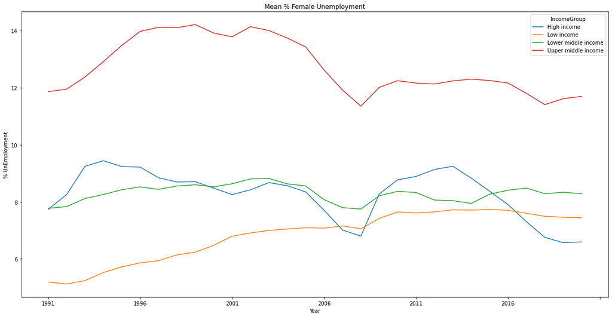

```python
transpose_income_group.plot(figsize=(20,10))
plt.title("Mean % Female Unemployment")
plt.xlabel("Year")
plt.ylabel("% UnEmployment")
```

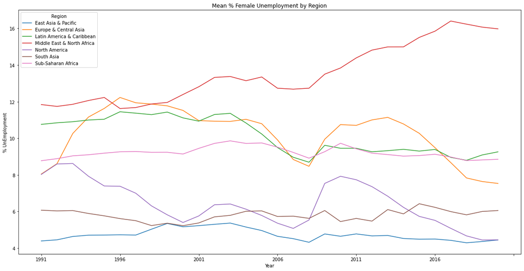

```python
grouped_data_region = merged_data_clean.groupby(['Region']).describe()
grouped_data_region = merged_data_clean.groupby(['Region']).mean()
transposed_region = grouped_data_region.transpose()
transposed_region.plot(figsize=(20,10))
plt.title('Mean % Female Unemployment by Region')
plt.xlabel('Year')
plt.ylabel("% UnEmployment")
```

## ANOVA

```python
import scipy.stats as stats
```

```python
merged_data_clean.head()
```

|  | Country Name | Country Code | 1991 | 1992 | 1993 | 1994 | 1995 | 1996 | 1997 | 1998 | 1999 | 2000 | 2001 | 2002 | 2003 | 2004 | 2005 | 2006 | 2007 | 2008 | 2009 | 2010 | 2011 | 2012 | 2013 | 2014 | 2015 | 2016 | 2017 | … |
| --- | --- | --- | --- | --- | --- | --- | --- | --- | --- | --- | --- | --- | --- | --- | --- | --- | --- | --- | --- | --- | --- | --- | --- | --- | --- | --- | --- | --- | --- | --- |
| 1 | Afghanistan | AFG | 14.226 | 14.348000 | 14.391 | 14.515000 | 14.803000 | 14.505000 | 14.699000 | 14.710 | 14.794 | 14.733000 | 14.702000 | 15.036 | 14.859 | 14.877000 | 14.910000 | 14.431000 | 14.724 | 14.154 | 14.911 | 14.815 | 14.781 | 14.820 | 14.680 | 14.505 | 14.427 | 14.314 | 14.090 | … |
| 2 | Angola | AGO | 2.637 | 2.723000 | 2.695 | 2.882000 | 2.948000 | 2.994000 | 2.876000 | 2.967 | 2.932 | 2.798000 | 2.811000 | 2.899 | 2.833 | 2.882000 | 2.852000 | 2.746000 | 2.723 | 2.710 | 2.845 | 10.922 | 7.718 | 7.788 | 7.772 | 7.719 | 7.681 | 7.563 | 7.467 | … |
| 3 | Albania | ALB | 15.804 | 16.247999 | 16.711 | 16.749001 | 16.766001 | 16.739000 | 16.434999 | 16.829 | 16.916 | 16.898001 | 16.992001 | 17.063 | 17.104 | 17.011999 | 16.919001 | 16.643999 | 16.399 | 13.752 | 15.734 | 15.881 | 13.762 | 11.467 | 13.345 | 15.153 | 17.098 | 14.573 | 12.563 | … |
| 6 | United Arab Emirates | ARE | 2.431 | 2.115000 | 2.259 | 2.259000 | 2.359000 | 2.441000 | 2.501000 | 2.513 | 2.529 | 2.718000 | 3.355000 | 3.978 | 5.107 | 6.390000 | 7.221000 | 6.682000 | 5.829 | 5.419 | 5.843 | 5.883 | 5.983 | 5.956 | 5.851 | 5.214 | 4.703 | 4.200 | 7.136 | … |
| 7 | Argentina | ARG | 5.747 | 6.711000 | 12.558 | 13.927000 | 22.195999 | 19.190001 | 17.631001 | 14.029 | 15.147 | 16.344999 | 17.191999 | 18.830 | 17.549 | 15.789000 | 13.561000 | 12.392000 | 10.544 | 9.720 | 9.855 | 9.196 | 8.496 | 8.811 | 8.484 | 8.383 | 8.851 | 9.118 | 9.464 | … |

## Income Groups and the length

```python
income_groups = merged_data_clean['IncomeGroup'].unique()
print(income_groups)
len(income_groups)
```

```
['Low income' 'Lower middle income' 'Upper middle income' 'High income']
```

```
4
```

### Verification of Number of countries

```python
from IPython.display import display
with pd.option_context('display.max_rows', 299, 'display.max_columns', 40):
    display(merged_data_clean) #need display to show all data
```

|  | Country Name | Country Code | 1991 | 1992 | 1993 | 1994 | 1995 | 1996 | 1997 | 1998 | 1999 | 2000 | 2001 | 2002 | 2003 | 2004 | 2005 | 2006 | 2007 | 2008 | 2009 | 2010 | 2011 | 2012 | 2013 | 2014 | 2015 | 2016 | 2017 | … |
| --- | --- | --- | --- | --- | --- | --- | --- | --- | --- | --- | --- | --- | --- | --- | --- | --- | --- | --- | --- | --- | --- | --- | --- | --- | --- | --- | --- | --- | --- | --- |
| 1 | Afghanistan | AFG | 14.226000 | 14.348000 | 14.391000 | 14.515000 | 14.803000 | 14.505000 | 14.699000 | 14.710000 | 14.794000 | 14.733000 | 14.702000 | 15.036000 | 14.859000 | 14.877000 | 14.910000 | 14.431000 | 14.724000 | 14.154000 | 14.911000 | 14.815000 | 14.781000 | 14.820000 | 14.680000 | 14.505000 | 14.427000 | 14.314000 | 14.090000 | … |
| 2 | Angola | AGO | 2.637000 | 2.723000 | 2.695000 | 2.882000 | 2.948000 | 2.994000 | 2.876000 | 2.967000 | 2.932000 | 2.798000 | 2.811000 | 2.899000 | 2.833000 | 2.882000 | 2.852000 | 2.746000 | 2.723000 | 2.710000 | 2.845000 | 10.922000 | 7.718000 | 7.788000 | 7.772000 | 7.719000 | 7.681000 | 7.563000 | 7.467000 | … |
| 3 | Albania | ALB | 15.804000 | 16.247999 | 16.711000 | 16.749001 | 16.766001 | 16.739000 | 16.434999 | 16.829000 | 16.916000 | 16.898001 | 16.992001 | 17.063000 | 17.104000 | 17.011999 | 16.919001 | 16.643999 | 16.399000 | 13.752000 | 15.734000 | 15.881000 | 13.762000 | 11.467000 | 13.345000 | 15.153000 | 17.098000 | 14.573000 | 12.563000 | … |
| 6 | United Arab Emirates | ARE | 2.431000 | 2.115000 | 2.259000 | 2.259000 | 2.359000 | 2.441000 | 2.501000 | 2.513000 | 2.529000 | 2.718000 | 3.355000 | 3.978000 | 5.107000 | 6.390000 | 7.221000 | 6.682000 | 5.829000 | 5.419000 | 5.843000 | 5.883000 | 5.983000 | 5.956000 | 5.851000 | 5.214000 | 4.703000 | 4.200000 | 7.136000 | … |
| 7 | Argentina | ARG | 5.747000 | 6.711000 | 12.558000 | 13.927000 | 22.195999 | 19.190001 | 17.631001 | 14.029000 | 15.147000 | 16.344999 | 17.191999 | 18.830000 | 17.549000 | 15.789000 | 13.561000 | 12.392000 | 10.544000 | 9.720000 | 9.855000 | 9.196000 | 8.496000 | 8.811000 | 8.484000 | 8.383000 | 8.851000 | 9.118000 | 9.464000 | … |
| 8 | Armenia | ARM | 2.188000 | 2.422000 | 7.499000 | 8.613000 | 10.265000 | 14.891000 | 17.125999 | 13.642000 | 15.212000 | 14.492000 | 13.817000 | 13.307000 | 12.666000 | 11.875000 | 11.258000 | 10.467000 | 9.767000 | 13.946000 | 19.681999 | 21.285000 | 19.652000 | 18.181999 | 18.139000 | 19.465000 | 19.252001 | 17.483999 | 17.471001 | … |
| 11 | Australia | AUS | 9.148000 | 9.925000 | 9.995000 | 9.360000 | 8.104000 | 8.235000 | 8.070000 | 7.326000 | 6.657000 | 6.060000 | 6.443000 | 6.161000 | 5.979000 | 5.536000 | 5.221000 | 4.923000 | 4.787000 | 4.573000 | 5.400000 | 5.377000 | 5.305000 | 5.326000 | 5.609000 | 6.172000 | 6.073000 | 5.779000 | 5.668000 | … |
| 12 | Austria | AUT | 3.544000 | 3.771000 | 4.500000 | 3.966000 | 4.899000 | 5.205000 | 5.272000 | 5.594000 | 4.756000 | 4.594000 | 4.128000 | 4.526000 | 4.337000 | 5.893000 | 5.858000 | 5.603000 | 5.301000 | 4.411000 | 5.085000 | 4.629000 | 4.584000 | 4.786000 | 5.294000 | 5.382000 | 5.308000 | 5.543000 | 5.031000 | … |
| 13 | Azerbaijan | AZE | 0.996000 | 1.949000 | 4.863000 | 6.671000 | 7.772000 | 8.855000 | 10.035000 | 10.942000 | 11.950000 | 12.765000 | 11.540000 | 10.370000 | 9.239000 | 8.053000 | 7.353000 | 6.333000 | 5.256000 | 4.931000 | 6.586000 | 6.925000 | 6.451000 | 6.094000 | 5.945000 | 5.839000 | 5.867000 | 5.908000 | 5.927000 | … |
| 14 | Burundi | BDI | 1.278000 | 1.315000 | 1.400000 | 1.405000 | 1.397000 | 1.435000 | 1.410000 | 1.387000 | 1.404000 | 1.386000 | 1.381000 | 1.418000 | 1.419000 | 1.386000 | 1.337000 | 1.246000 | 1.166000 | 1.145000 | 1.280000 | 1.294000 | 1.259000 | 1.237000 | 1.217000 | 1.155000 | 1.126000 | 1.123000 | 1.073000 | … |
| 15 | Belgium | BEL | 10.652000 | 9.505000 | 10.820000 | 12.429000 | 12.214000 | 12.409000 | 11.546000 | 11.704000 | 10.215000 | 8.282000 | 6.922000 | 7.799000 | 7.996000 | 8.283000 | 9.512000 | 9.314000 | 8.448000 | 7.600000 | 8.106000 | 8.516000 | 7.180000 | 7.409000 | 8.170000 | 7.940000 | 7.768000 | 7.560000 | 7.054000 | … |
| 16 | Benin | BEN | 0.547000 | 0.580000 | 0.617000 | 0.603000 | 0.622000 | 0.583000 | 0.572000 | 0.536000 | 0.541000 | 0.497000 | 0.458000 | 0.427000 | 0.501000 | 0.570000 | 0.619000 | 0.677000 | 0.724000 | 0.781000 | 0.991000 | 1.146000 | 2.872000 | 2.884000 | 2.919000 | 2.835000 | 2.776000 | 2.748000 | 2.664000 | … |
| 17 | Burkina Faso | BFA | 2.631000 | 2.569000 | 2.698000 | 2.685000 | 2.689000 | 2.667000 | 2.583000 | 2.585000 | 2.698000 | 2.733000 | 2.878000 | 2.992000 | 3.146000 | 3.795000 | 4.620000 | 4.223000 | 3.928000 | 4.463000 | 5.368000 | 6.209000 | 6.898000 | 7.750000 | 8.682000 | 9.506000 | 9.388000 | 9.320000 | 9.130000 | … |
| 18 | Bangladesh | BGD | 2.082000 | 2.121000 | 2.115000 | 2.122000 | 2.118000 | 2.116000 | 2.382000 | 2.646000 | 3.005000 | 3.332000 | 3.715000 | 4.248000 | 4.841000 | 5.951000 | 7.084000 | 6.494000 | 6.591000 | 6.734000 | 7.385000 | 4.440000 | 5.395000 | 6.432000 | 7.609000 | 7.522000 | 7.467000 | 7.379000 | 6.745000 | … |
| 19 | Bulgaria | BGR | 13.123000 | 13.238000 | 13.314000 | 13.445000 | 13.507000 | 13.407000 | 13.489000 | 11.775000 | 14.154000 | 15.812000 | 18.857000 | 17.358999 | 13.191000 | 11.621000 | 9.833000 | 9.301000 | 7.292000 | 5.760000 | 6.621000 | 9.606000 | 10.107000 | 10.839000 | 11.844000 | 10.404000 | 8.416000 | 6.968000 | 5.946000 | … |
| 20 | Bahrain | BHR | 3.874000 | 3.897000 | 4.943000 | 4.540000 | 4.396000 | 4.249000 | 3.973000 | 4.027000 | 4.813000 | 4.485000 | 4.394000 | 3.770000 | 3.943000 | 4.210000 | 3.602000 | 3.172000 | 2.692000 | 2.598000 | 3.709000 | 3.704000 | 4.023000 | 3.894000 | 4.209000 | 3.893000 | 3.745000 | 3.280000 | 2.792000 | … |
| 21 | Bahamas, The | BHS | 12.100000 | 15.854000 | 13.032000 | 15.243000 | 11.758000 | 14.700000 | 11.387000 | 9.851000 | 9.299000 | 8.021000 | 7.031000 | 9.515000 | 11.800000 | 11.035000 | 11.201000 | 8.057000 | 9.107000 | 9.261000 | 14.035000 | 15.054000 | 15.362000 | 13.968000 | 16.259001 | 14.641000 | 13.004000 | 14.483000 | 11.391000 | … |
| 22 | Bosnia and Herzegovina | BIH | 21.281000 | 22.247999 | 23.260000 | 24.559000 | 25.451000 | 26.624001 | 27.228001 | 28.110001 | 28.975000 | 29.695000 | 30.593000 | 31.816000 | 32.723999 | 33.605000 | 34.344002 | 34.868999 | 32.948002 | 26.797001 | 25.648001 | 29.931000 | 29.926001 | 30.649000 | 28.915001 | 31.118999 | 30.653999 | 29.976999 | 23.099001 | … |
| 23 | Belarus | BLR | 0.118000 | 1.892000 | 6.757000 | 10.721000 | 15.384000 | 22.198000 | 15.128000 | 12.038000 | 10.809000 | 10.124000 | 9.388000 | 8.784000 | 8.173000 | 7.548000 | 6.834000 | 6.154000 | 5.497000 | 4.993000 | 4.629000 | 4.741000 | 4.634000 | 4.552000 | 4.532000 | 4.423000 | 4.262000 | 4.186000 | 4.039000 | … |
| 24 | Belize | BLZ | 15.028000 | 14.397000 | 14.377000 | 15.723000 | 18.058001 | 18.667999 | 20.756001 | 21.794001 | 20.629000 | 18.291000 | 15.505000 | 15.165000 | 16.040001 | 16.530001 | 17.205999 | 15.073000 | 13.124000 | 12.795000 | 12.948000 | 12.956000 | 12.810000 | 12.726000 | 12.582000 | 14.009000 | 11.065000 | 11.115000 | 9.801000 | … |
| 26 | Bolivia | BOL | 3.504000 | 3.431000 | 3.662000 | 3.654000 | 3.659000 | 3.668000 | 3.695000 | 3.704000 | 3.571000 | 3.671000 | 3.597000 | 3.697000 | 3.685000 | 3.670000 | 3.610000 | 3.485000 | 3.375000 | 3.396000 | 3.457000 | 3.077000 | 2.670000 | 2.802000 | 2.973000 | 2.847000 | 3.797000 | 4.075000 | 4.071000 | … |
| 27 | Brazil | BRA | 8.169000 | 8.098000 | 7.446000 | 7.818000 | 8.113000 | 9.567000 | 10.874000 | 12.597000 | 13.321000 | 12.886000 | 12.222000 | 11.861000 | 12.664000 | 11.987000 | 12.535000 | 11.375000 | 11.135000 | 9.947000 | 11.365000 | 10.636000 | 9.439000 | 9.059000 | 8.771000 | 8.114000 | 10.055000 | 13.458000 | 14.718000 | … |
| 28 | Barbados | BRB | 23.796000 | 25.673000 | 27.716999 | 27.976000 | 22.862000 | 17.768999 | 18.025999 | 16.540001 | 13.478000 | 11.391000 | 11.811000 | 12.207000 | 12.557000 | 10.451000 | 10.799000 | 9.814000 | 8.431000 | 9.430000 | 9.887000 | 10.472000 | 12.629000 | 12.263000 | 11.433000 | 12.652000 | 10.322000 | 10.103000 | 10.042000 | … |
| 29 | Brunei Darussalam | BRN | 6.712000 | 7.120000 | 7.493000 | 7.596000 | 7.775000 | 7.664000 | 7.364000 | 7.271000 | 7.434000 | 7.308000 | 7.365000 | 7.551000 | 7.595000 | 7.314000 | 7.006000 | 6.765000 | 6.488000 | 6.286000 | 7.537000 | 7.967000 | 8.065000 | 8.215000 | 8.226000 | 7.902000 | 8.798000 | 9.490000 | 9.985000 | … |
| 30 | Bhutan | BTN | 1.267000 | 1.303000 | 1.355000 | 1.375000 | 1.418000 | 1.414000 | 1.398000 | 1.400000 | 1.635000 | 2.190000 | 2.871000 | 2.766000 | 2.566000 | 3.308000 | 3.330000 | 3.798000 | 4.733000 | 4.948000 | 5.535000 | 4.054000 | 4.875000 | 2.215000 | 3.765000 | 3.610000 | 3.245000 | 3.227000 | 3.158000 | … |
| 31 | Botswana | BWA | 16.924999 | 18.840000 | 21.184999 | 22.976999 | 23.764999 | 24.114000 | 23.959999 | 23.650999 | 20.580999 | 17.250999 | 22.069000 | 24.480000 | 26.485001 | 24.302999 | 22.237000 | 20.176001 | 19.860001 | 19.655001 | 19.707001 | 21.535999 | 21.301001 | 21.275000 | 21.351999 | 20.971001 | 20.844000 | 20.905001 | 20.649000 | … |
| 32 | Central African Republic | CAF | 3.624000 | 3.661000 | 3.762000 | 3.793000 | 3.782000 | 3.759000 | 3.797000 | 3.770000 | 3.833000 | 3.802000 | 3.808000 | 3.864000 | 3.848000 | 3.825000 | 3.750000 | 3.619000 | 3.500000 | 3.471000 | 3.744000 | 3.821000 | 3.816000 | 3.847000 | 3.798000 | 3.916000 | 3.769000 | 3.708000 | 3.624000 | … |
| 33 | Canada | CAN | 9.687000 | 10.188000 | 10.674000 | 9.793000 | 9.113000 | 9.287000 | 8.918000 | 7.986000 | 7.292000 | 6.694000 | 6.855000 | 7.123000 | 7.156000 | 6.852000 | 6.463000 | 6.092000 | 5.648000 | 5.649000 | 7.007000 | 7.233000 | 7.007000 | 6.820000 | 6.596000 | 6.389000 | 6.285000 | 6.238000 | 5.849000 | … |
| 35 | Switzerland | CHE | 2.517000 | 3.529000 | 4.567000 | 4.422000 | 3.920000 | 4.084000 | 3.989000 | 4.135000 | 3.568000 | 3.130000 | 3.457000 | 3.096000 | 4.486000 | 4.763000 | 5.091000 | 4.709000 | 4.513000 | 3.966000 | 4.520000 | 5.188000 | 4.800000 | 4.729000 | 4.918000 | 4.986000 | 4.912000 | 5.006000 | 5.058000 | … |
| 36 | Channel Islands | CHI | 7.909000 | 8.055000 | 8.350000 | 8.394000 | 8.417000 | 8.362000 | 8.310000 | 8.218000 | 8.244000 | 8.236000 | 8.100000 | 8.013000 | 8.024000 | 7.944000 | 7.890000 | 7.694000 | 7.527000 | 7.576000 | 8.371000 | 8.566000 | 8.566000 | 8.664000 | 8.727000 | 8.515000 | 8.326000 | 8.110000 | 7.884000 | … |

[output cut: 157 more lines]

```python
#how many partipant countries
CC_countries = merged_data_clean['Country Code'].unique()
print(CC_countries)
print(len(CC_countries))
```

```
['AFG' 'AGO' 'ALB' 'ARE' 'ARG' 'ARM' 'AUS' 'AUT' 'AZE' 'BDI' 'BEL' 'BEN'
 'BFA' 'BGD' 'BGR' 'BHR' 'BHS' 'BIH' 'BLR' 'BLZ' 'BOL' 'BRA' 'BRB' 'BRN'
 'BTN' 'BWA' 'CAF' 'CAN' 'CHE' 'CHI' 'CHL' 'CHN' 'CIV' 'CMR' 'COD' 'COG'
 'COL' 'COM' 'CPV' 'CRI' 'CUB' 'CYP' 'CZE' 'DEU' 'DJI' 'DNK' 'DOM' 'DZA'
 'ECU' 'EGY' 'ERI' 'ESP' 'EST' 'ETH' 'FIN' 'FJI' 'FRA' 'GAB' 'GBR' 'GEO'
 'GHA' 'GIN' 'GMB' 'GNB' 'GNQ' 'GRC' 'GTM' 'GUM' 'GUY' 'HKG' 'HND' 'HRV'
 'HTI' 'HUN' 'IDN' 'IND' 'IRL' 'IRN' 'IRQ' 'ISL' 'ISR' 'ITA' 'JAM' 'JOR'
 'JPN' 'KAZ' 'KEN' 'KGZ' 'KHM' 'KOR' 'KWT' 'LAO' 'LBN' 'LBR' 'LBY' 'LCA'
 'LKA' 'LSO' 'LTU' 'LUX' 'LVA' 'MAC' 'MAR' 'MDA' 'MDG' 'MDV' 'MEX' 'MKD'
 'MLI' 'MLT' 'MMR' 'MNE' 'MNG' 'MOZ' 'MRT' 'MUS' 'MWI' 'MYS' 'NAM' 'NCL'
 'NER' 'NGA' 'NIC' 'NLD' 'NOR' 'NPL' 'NZL' 'OMN' 'PAK' 'PAN' 'PER' 'PHL'
 'PNG' 'POL' 'PRI' 'PRK' 'PRT' 'PRY' 'PSE' 'PYF' 'QAT' 'ROU' 'RUS' 'RWA'
 'SAU' 'SDN' 'SEN' 'SGP' 'SLB' 'SLE' 'SLV' 'SOM' 'SRB' 'SSD' 'STP' 'SUR'
 'SVK' 'SVN' 'SWE' 'SWZ' 'SYR' 'TCD' 'TGO' 'THA' 'TJK' 'TKM' 'TLS' 'TON'
 'TTO' 'TUN' 'TUR' 'TZA' 'UGA' 'UKR' 'URY' 'USA' 'UZB' 'VCT' 'VEN' 'VIR'
 'VNM' 'VUT' 'WSM' 'YEM' 'ZAF' 'ZMB' 'ZWE']
187
```

```python
CC_IG = merged_data_clean[['Country Code','IncomeGroup']]
print(CC_IG)
print(len(CC_IG))
```

```
    Country Code          IncomeGroup
1            AFG           Low income
2            AGO  Lower middle income
3            ALB  Upper middle income
6            ARE          High income
7            ARG  Upper middle income
..           ...                  ...
257          WSM  Upper middle income
259          YEM           Low income
260          ZAF  Upper middle income
261          ZMB  Lower middle income
262          ZWE  Lower middle income

[187 rows x 2 columns]
187
```

```python
CC_IG_GP= CC_IG.groupby(['Country Code']).describe()
print(CC_IG_GP)
print(len(CC_IG_GP))
```

```
             IncomeGroup
                   count unique                  top freq
Country Code
AFG                    1      1           Low income    1
AGO                    1      1  Lower middle income    1
ALB                    1      1  Upper middle income    1
ARE                    1      1          High income    1
ARG                    1      1  Upper middle income    1
...                  ...    ...                  ...  ...
WSM                    1      1  Upper middle income    1
YEM                    1      1           Low income    1
ZAF                    1      1  Upper middle income    1
ZMB                    1      1  Lower middle income    1
ZWE                    1      1  Lower middle income    1

[187 rows x 4 columns]
187
```

```python
IG_IG_GP= CC_IG.groupby(['IncomeGroup']).describe()
print(IG_IG_GP)
print(len(IG_IG_GP))
```

```
                    Country Code
                           count unique  top freq
IncomeGroup
High income                   60     60  PRI    1
Low income                    29     29  HTI    1
Lower middle income           48     48  KHM    1
Upper middle income           50     50  SRB    1
4
```

```python
CC_IG_2019 = merged_data_clean[['Country Code','2019','IncomeGroup']]
print(CC_IG_2019)
print(len(CC_IG_2019))
```

```
    Country Code       2019          IncomeGroup
1            AFG  14.004000           Low income
2            AGO   6.942000  Lower middle income
3            ALB  11.604000  Upper middle income
6            ARE   6.046000          High income
7            ARG  10.922000  Upper middle income
..           ...        ...                  ...
257          WSM   9.837000  Upper middle income
259          YEM  24.879999           Low income
260          ZAF  30.334999  Upper middle income
261          ZMB  12.237000  Lower middle income
262          ZWE   5.458000  Lower middle income

[187 rows x 3 columns]
187
```

```python
import statistics
grouped_data_income = merged_data_clean.groupby(['IncomeGroup']).mean()
grouped_data_income
#grouped_data_income_2019= grouped_data_income(['2019'])
#Data2019=merged_data_clean['2019']
#mode = statistics.mode(transpose_income_group.groupby([]))
#print(mode)
```

| IncomeGroup | 1991 | 1992 | 1993 | 1994 | 1995 | 1996 | 1997 | 1998 | 1999 | 2000 | 2001 | 2002 | 2003 | 2004 | 2005 | 2006 | 2007 | 2008 | 2009 | 2010 | 2011 | 2012 | 2013 | 2014 | 2015 | 2016 | 2017 | 2018 | 2019 | … |
| --- | --- | --- | --- | --- | --- | --- | --- | --- | --- | --- | --- | --- | --- | --- | --- | --- | --- | --- | --- | --- | --- | --- | --- | --- | --- | --- | --- | --- | --- | --- |
| High income | 7.736467 | 8.250783 | 9.243850 | 9.437617 | 9.237233 | 9.212950 | 8.843950 | 8.693183 | 8.703783 | 8.479150 | 8.252700 | 8.419200 | 8.672367 | 8.563100 | 8.345683 | 7.703300 | 7.011633 | 6.799433 | 8.279067 | 8.769983 | 8.888267 | 9.132533 | 9.244683 | 8.827083 | 8.370100 | 7.900950 | 7.301283 | 6.753733 | 6.569350 | … |
| Low income | 5.191034 | 5.122586 | 5.241103 | 5.521621 | 5.722138 | 5.862035 | 5.939793 | 6.142310 | 6.236034 | 6.476931 | 6.796276 | 6.910207 | 6.998379 | 7.046828 | 7.092172 | 7.077345 | 7.154931 | 7.056069 | 7.421069 | 7.645621 | 7.609897 | 7.646276 | 7.719931 | 7.709862 | 7.734690 | 7.701448 | 7.599138 | 7.491828 | 7.458897 | … |
| Lower middle income | 7.770750 | 7.832417 | 8.115313 | 8.255917 | 8.423167 | 8.522042 | 8.436583 | 8.552500 | 8.596146 | 8.522167 | 8.632187 | 8.800479 | 8.815729 | 8.629063 | 8.552938 | 8.074896 | 7.795771 | 7.745271 | 8.212021 | 8.366792 | 8.326208 | 8.061479 | 8.041271 | 7.941438 | 8.267479 | 8.405146 | 8.481042 | 8.283375 | 8.333917 | … |
| Upper middle income | 11.855680 | 11.943880 | 12.369380 | 12.909100 | 13.475140 | 13.965980 | 14.108920 | 14.097900 | 14.203700 | 13.907960 | 13.776640 | 14.130820 | 13.996420 | 13.734020 | 13.419940 | 12.613340 | 11.910920 | 11.348980 | 12.007120 | 12.239020 | 12.157240 | 12.124720 | 12.233620 | 12.294740 | 12.246720 | 12.158600 | 11.795040 | 11.403020 | 11.610500 | … |

```python
income_groups
print(income_groups)
income_groups[0]
for income_group in income_groups:
  print(income_group)
```

```
['Low income' 'Lower middle income' 'Upper middle income' 'High income']
Low income
Lower middle income
Upper middle income
High income
```

```python
income_group_data=[]
for i in range (len(income_groups)):
  income_group_data.append(merged_data_clean['2019'][merged_data_clean['IncomeGroup']==income_groups[i]])
```

```python
income_group_data
```

```
[1      14.004000
 14      1.009000
 17      9.223000
 32      3.565000
 41      3.404000
 67      4.953000
 70      2.756000
 83      3.316000
 84     12.237000
 85      2.210000
 98     16.693001
 128     2.224000
 148     1.846000
 155     7.954000
 162     3.453000
```

[output cut: 173 more lines]

```python
statistic, pvalue = stats.f_oneway(income_group_data[0],
                                   income_group_data[1],
                                   income_group_data[2],
                                   income_group_data[3])
print("statistic: %s pvalue %s" %(statistic,pvalue))
```

```
statistic: 5.052886221006664 pvalue 0.0021894356280740147
```

```python
regions = merged_data_clean['Region'].unique()
print(regions)


regions_data=[]
for i in range (len(regions)):
  regions_data.append(merged_data_clean['2019'][merged_data_clean['Region']==regions[i]])



statistic, pvalue = stats.f_oneway(regions_data[0],
                                   regions_data[1],
                                   regions_data[2],
                                   regions_data[3],regions_data[4],
                                   regions_data[5],regions_data[6])
print("statistic: %s pvalue %s" %(statistic,pvalue))
```

```
['South Asia' 'Sub-Saharan Africa' 'Europe & Central Asia'
 'Middle East & North Africa' 'Latin America & Caribbean'
 'East Asia & Pacific' 'North America']
statistic: 7.031185985789595 pvalue 9.75436578876421e-07
```

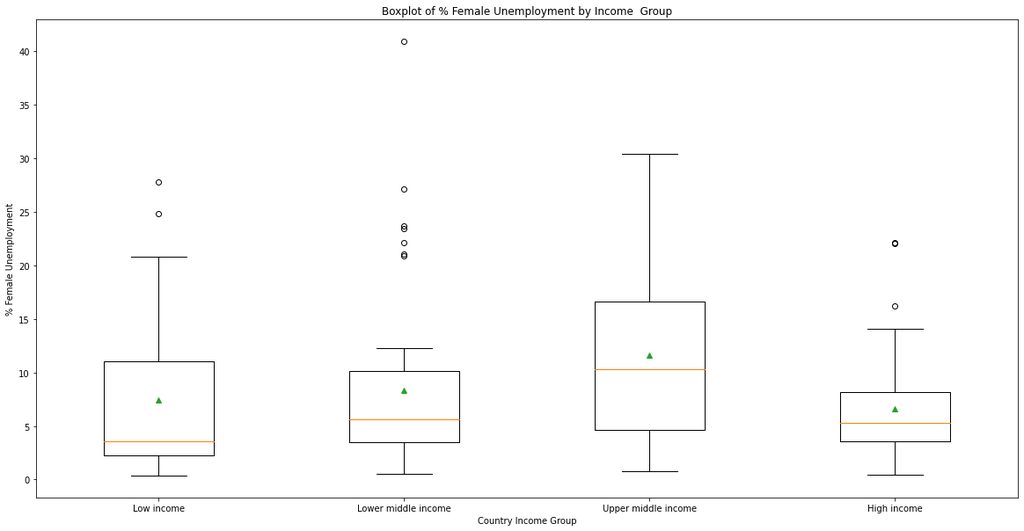

```python
fig = plt.figure(figsize=(20,10))
ax = fig.add_subplot(111)
ax.set_title("Boxplot of % Female Unemployment by Income  Group")
ax.set
ax.boxplot(income_group_data, labels = income_groups, showmeans =True)
plt.xlabel("Country Income Group")
plt.ylabel("% Female Unemployment")
plt.show()
```

### Median is the orange line in graph above

### The mean for each group is the green triangle

# **ANOVA Step by Step**

## Defining ANOVA

### Objective

In our case, the impact of the factor Income Group to the different means of the % Female Unemployment will be analysed.

## Hypotesis testing in ANOVA:

[Hypothesis Testing - Analysis of Variance (ANOVA)](https://sphweb.bumc.bu.edu/otlt/MPH-Modules/BS/BS704_HypothesisTesting-ANOVA/BS704_HypothesisTesting-Anova_print.html)

The null hypothesis in ANOVA is always that there is no difference in means.

H0: mu1=mu2=mu3=mu4

The alternative hypothesis is always that the means are not all equal

H1: means are not all equal

### Test Statistic for ANOVA

And follows the table of calculations:

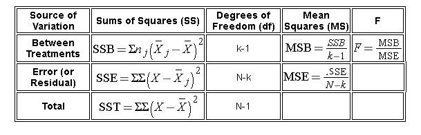

# ANOVA Step By Step

Assumptions while calculating test statisitic F:

- Equal variability in the 4 income groups (e.g population variances are equal s1^2 = s2^2 = s3^2= s4^2

## Sample Data

Groups are the income groups: IG1, IG2, IG3, IG4

Sample Size for each group: n1 =60, n2=29, n3=48,n4=50

Sample mean: mu1, mu2, mu3, mu4

Sample standard deviation: s1,s2,s3,s4

### Preparing all sample data (K= number of samples, N=population, degrees of freedom 1 and 2

```python
k=len(pd.unique(merged_data_clean.IncomeGroup))
N=len(merged_data_clean.values)
#Degrees of Freedom Between Treatments
df1= k-1
#Degrees of Freedom within Treatments
df2 = N-k
#Total Degrees of Freedom
dfT=N-1
print(k,N, df1, df2, dfT)
```

```
4 187 3 183 186
```

### Calculating the populations of each income group and N

```python
n0=merged_data_clean.groupby('IncomeGroup').size()[0]
n1=merged_data_clean.groupby('IncomeGroup').size()[1]
n2=merged_data_clean.groupby('IncomeGroup').size()[2]
n3=merged_data_clean.groupby('IncomeGroup').size()[3]
N=n0+n1+n2+n3
print(n0,n1,n2,n3,n0+n1+n2+n3)
```

```
60 29 48 50 187
```

```python
grandmu=(merged_data_clean['2019'].sum()/N)
print(grandmu)
```

```
8.50813905424613
```

### Sum of Squares Between Samples

We start by calculating the Sum of Squares between. Sum of Squares Between is the variability due to interaction between the groups. Sometimes known as the Sum of Squares of the Model.

```python
print(n0,n1,n2,n3)
merged_data_clean_IG_2019=merged_data_clean[['2019','IncomeGroup']]
IG0=merged_data_clean_IG_2019[merged_data_clean_IG_2019['IncomeGroup']=='High income']
IG1=merged_data_clean_IG_2019[merged_data_clean_IG_2019['IncomeGroup']=='Low income']
IG2=merged_data_clean_IG_2019[merged_data_clean_IG_2019['IncomeGroup']=='Lower middle income']
IG3=merged_data_clean_IG_2019[merged_data_clean_IG_2019['IncomeGroup']=='Upper middle income']

IG0mu_2=((sum(IG0['2019']))/n0)
IG1mu_2=((sum(IG1['2019']))/n1)
IG2mu_2=((sum(IG2['2019']))/n2)
IG3mu_2=((sum(IG3['2019']))/n3)

SSB= n0*(IG0mu_2 -grandmu )**2 + n1*(IG1mu_2-grandmu)**2 + n2*(IG2mu_2-grandmu)**2 + n3*(IG3mu_2-grandmu)**2
SSB
```

```
60 29 48 50
```

```
740.1497027860728
```

### Mean Square for SSB

```python
MSSB= SSB/df1
MSSB
```

```
246.7165675953576
```

### How to Calculate the Sum of Squares Within

The variability in the data due to differences within each group.

```python
import statistics
IG0_ss=statistics.pvariance(IG0['2019'])
IG1_ss=statistics.pvariance(IG1['2019'])
IG2_ss=statistics.pvariance(IG2['2019'])
IG3_ss=statistics.pvariance(IG3['2019'])
#this calculation was not included in SSW. it didnt result in an accurate
```

```python
def variance(datav, ddof=1):
      n = len(datav)
      mean = sum(datav) / n
      return sum((x - mean) ** 2 for x in datav) / (n - ddof)
IG0_sss=variance(IG0['2019'])
IG1_sss=variance(IG1['2019'])
IG2_sss=variance(IG2['2019'])
IG3_sss=variance(IG3['2019'])
```

```python
SSW=(n0-1)*IG0_sss +(n1-1)*IG1_sss +(n2-1)*IG2_sss +(n3-1)*IG3_sss
SSW
```

```
8935.315361396688
```

### Mean Square for SSW

```python
MSSW = SSW/df2
MSSW
```

```
48.826859898342555
```

## Calculating the F-value

```python
F=MSSB/MSSW
F
```

```
5.0528862210066565
```

### Calculating p

```python
from scipy import stats
p= stats.f.sf(F,dfT, df2)
p
```

[output not shown]

# Interpretation of F

We reject the null hypothesis H0 because p<= 0.05

The % of Female Unemployment rate was measured across different income groups.

The purpose of calculating ANOVA was to see if averages of the values of % of Female Unemployment across the different Income Groups were statistically different.

```python
!pip install researchpy
```

```python
import researchpy as rp
rp.summary_cont(merged_data_clean['2019'])
```

|  | Variable | N | Mean | SD | SE | 95% Conf. | Interval |
| --- | --- | --- | --- | --- | --- | --- | --- |
| 0 | 2019 | 187.0 | 8.5081 | 7.2124 | 0.5274 | 7.4676 | 9.5486 |

```python
rp.summary_cont(merged_data_clean_IG_2019.groupby(merged_data_clean_IG_2019['IncomeGroup']))
```

| IncomeGroup | 2019 N | 2019 Mean | 2019 SD | 2019 SE | 2019 95% Conf. | 2019 Interval |
| --- | --- | --- | --- | --- | --- | --- |
| High income | 60 | 6.5694 | 4.3386 | 0.5601 | 5.4486 | 7.6901 |
| Low income | 29 | 7.4589 | 7.4468 | 1.3828 | 4.6263 | 10.2915 |
| Lower middle income | 48 | 8.3339 | 8.2012 | 1.1837 | 5.9525 | 10.7153 |
| Upper middle income | 50 | 11.6105 | 7.9678 | 1.1268 | 9.3461 | 13.8749 |

### Calculation of Sum of Squares Total

Sum of Squares Total will be needed to calculate eta-squared later. This is the total variability in the data:

```python
SStotal = SSB+SSW
SStotal
```

```
9675.465064182761
```

# ANOVA with Pingouin

Install the library

```python
#One-Way ANOVA
!pip install pingouin
import pingouin as pg
```

```
     |████████████████████████████████| 225kB 4.4MB/s
```

### ANOVA Table to study variability of the data (between and within samples)

```python
aov= pg.anova(dv='2019', between='IncomeGroup',data= merged_data_clean,detailed=True)
aov
```

|  | Source | SS | DF | MS | F | p-unc | np2 |
| --- | --- | --- | --- | --- | --- | --- | --- |
| 0 | IncomeGroup | 740.149703 | 3 | 246.716568 | 5.052886 | 0.002189 | 0.076498 |
| 1 | Within | 8935.315361 | 183 | 48.826860 | NaN | NaN | NaN |

the impact of the factor Region to the different means of the % Female Unemployment

```python
aov= pg.anova(dv='2019', between='Region',data= merged_data_clean,detailed=True)
aov
```

|  | Source | SS | DF | MS | F | p-unc | np2 |
| --- | --- | --- | --- | --- | --- | --- | --- |
| 0 | Region | 1837.100070 | 6 | 306.183345 | 7.031186 | 9.754366e-07 | 0.189872 |
| 1 | Within | 7838.364994 | 180 | 43.546472 | NaN | NaN | NaN |